# Lab 6 - Classification and Regression Trees (CART)

- Regression Trees
  - Preparation
  - Fitting Regression Tree
    - Printing and Plotting the Tree
  - Prediction Using Regression Tree
  - Comparing the Performance of Regression Tree with Linear Regression Model
- Classification Trees
  - Preparation
  - Fitting Classification Tree
    - Printing and Plotting the Tree
  - Prediction Using Classification Tree
  - Calculate the Actual Cost Using a Self-Defined Cost Function
  - Comparing the Performance of Classification Tree with Logistic Regression Model
  - ROC Curve for Classification Tree
- Pruning
- Summary

In this lab, we will go through model building, validation, and interpretation of tree models. The focus will be on the ‘rpart’ package. Recall that when the response variable *Y* is continuous, we fit a regression tree; when the response variable *Y* is categorical, we fit a classification tree. We will build tree models for our familiar datasets - Boston Housing and Credit Default - for regression and classification purposes, respectively.

# Regression Trees

## Preparation

Load the data and randomly split into training and validation samples.

```r
housing.df <- read.csv("BostonHousing.csv")
housing.df$RAD <- as.factor(housing.df$RAD) # convert to factor
housing.df <- housing.df[, -14]
str(housing.df)
```

```
## 'data.frame':    506 obs. of  13 variables:
##  $ CRIM   : num  0.00632 0.02731 0.02729 0.03237 0.06905 ...
##  $ ZN     : num  18 0 0 0 0 0 12.5 12.5 12.5 12.5 ...
##  $ INDUS  : num  2.31 7.07 7.07 2.18 2.18 2.18 7.87 7.87 7.87 7.87 ...
##  $ CHAS   : int  0 0 0 0 0 0 0 0 0 0 ...
##  $ NOX    : num  0.538 0.469 0.469 0.458 0.458 0.458 0.524 0.524 0.524 0.524 ...
##  $ RM     : num  6.58 6.42 7.18 7 7.15 ...
##  $ AGE    : num  65.2 78.9 61.1 45.8 54.2 58.7 66.6 96.1 100 85.9 ...
##  $ DIS    : num  4.09 4.97 4.97 6.06 6.06 ...
##  $ RAD    : Factor w/ 9 levels "1","2","3","4",..: 1 2 2 3 3 3 5 5 5 5 ...
##  $ TAX    : int  296 242 242 222 222 222 311 311 311 311 ...
##  $ PTRATIO: num  15.3 17.8 17.8 18.7 18.7 18.7 15.2 15.2 15.2 15.2 ...
##  $ LSTAT  : num  4.98 9.14 4.03 2.94 5.33 ...
##  $ MEDV   : num  24 21.6 34.7 33.4 36.2 28.7 22.9 27.1 16.5 18.9 ...
```

```r
# partition the data
set.seed(5)
train.index <- sample(nrow(housing.df), nrow(housing.df) * 0.9)
valid.index <- as.numeric(setdiff(rownames(housing.df), train.index))
housing.train <- housing.df[train.index, ]
housing.valid <- housing.df[valid.index, ]
```

We will use the ‘rpart’ library for model building and ‘rpart.plot’ for plotting.

```r
install.packages("rpart")
install.packages("rpart.plot")
```

```r
library(rpart)
library(rpart.plot)
```

## Fitting Regression Tree

The simple form of the rpart() function is similar to lm() and glm(). It takes a formula argument in which you specify the response and predictor variables and a data argument in which you specify the data frame.

```r
housing.rt <- rpart(MEDV ~ ., data = housing.train)
```

### Printing and Plotting the Tree

```r
housing.rt
```

```
## n= 455
##
## node), split, n, deviance, yval
##       * denotes terminal node
##
##  1) root 455 39394.7500 22.86571
##    2) RM< 6.9715 388 15996.0500 20.21057
##      4) LSTAT>=14.4 151  3159.2690 15.02583
##        8) NOX>=0.607 90  1269.5180 12.75889
##         16) LSTAT>=19.645 49   447.4384 10.55918 *
##         17) LSTAT< 19.645 41   301.6239 15.38780 *
##        9) NOX< 0.607 61   744.8469 18.37049 *
##      5) LSTAT< 14.4 237  6191.4840 23.51392
##       10) RM< 6.543 183  3926.3490 22.18689
##         20) DIS>=1.6141 176  1437.3700 21.77500 *
##         21) DIS< 1.6141 7  1708.3970 32.54286 *
##       11) RM>=6.543 54   850.7333 28.01111 *
##    3) RM>=6.9715 67  4822.9830 38.24179
##      6) RM< 7.437 37  1171.4700 32.68378 *
##      7) RM>=7.437 30  1098.8500 45.09667 *
```

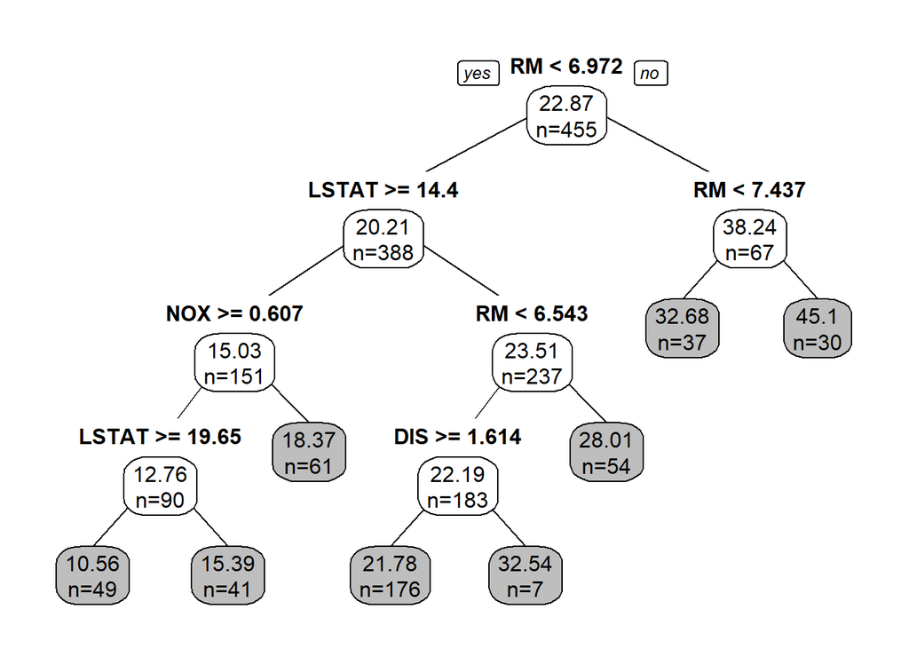

```r
prp(housing.rt, digits = 4, type = 1, extra = 1, varlen = -10,
    box.col = ifelse(housing.rt$frame$var == "<leaf>", 'gray', 'white'))
```

Be sure you understand how to interpret this tree model.

**Exercise:** What is the predicted median housing price (in thousands) for a census tract with the following predictor values?

| CRIM | ZN | INDUS | CHAS | NOX | RM | AGE | DIS | RAD | TAX | PTRATIO | LSTAT |
| --- | --- | --- | --- | --- | --- | --- | --- | --- | --- | --- | --- |
| 0.04 | 25 | 4.86 | 0 | 0.43 | 6.3 | 32.2 | 5.4 | 4 | 281 | 19 | 6.72 |

## Prediction Using Regression Tree

The in-sample (training) prediction and out-of-sample (validation) prediction for regression trees are also similar to lm() and glm() models.

In-Sample Prediction:

```r
housing.train.rt.pred <- predict(housing.rt)
library(caret)
RMSE(housing.train.rt.pred, housing.train$MEDV)
```

```
## [1] 4.129957
```

Out-of-Sample Prediction:

```r
housing.valid.rt.pred <- predict(housing.rt, newdata = housing.valid)
RMSE(housing.valid.rt.pred, housing.valid$MEDV)
```

```
## [1] 4.576376
```

## Comparing the Performance of Regression Tree with Linear Regression Model (Exercise)

Calculate the in-sample and out-of-sample root mean square error (RMSE) for a linear regression model using all variables. Then compare the results. What is your conclusion?

```r
housing.lm <-
housing.train.lm.pred <-
housing.valid.lm.pred <-
RMSE.lm.train <-
RMSE.lm.valid <-
```

# Classification Trees

## Preparation

Load the data, rename the response variable (to something more succinct), convert categorical variables to factors, and randomly split into training and validation samples.

```r
credit.data <- read.csv("credit_default.csv")

# rename
library(dplyr)
credit.data <- rename(credit.data, default = default.payment.next.month)

# convert categorical data to factors
credit.data$SEX <- as.factor(credit.data$SEX)
credit.data$EDUCATION <- as.factor(credit.data$EDUCATION)
credit.data$MARRIAGE <- as.factor(credit.data$MARRIAGE)

# partitioning the data
set.seed(11)
index <- sample(nrow(credit.data),nrow(credit.data)*0.80)
credit.train = credit.data[index,]
credit.valid = credit.data[-index,]
```

## Fitting Classification Tree

You will need to specify in R that you want a classification tree. You do this by specifying method=“class” since the default is to fit a regression tree.

```r
credit.ct0 <- rpart(default ~ ., data = credit.train, method = "class")
```

This tree minimizes the symmetric cost, which is the misclassification rate. We can take a look at the confusion matrix.

```r
pred0 <- predict(credit.ct0, type = "class")
confusionMatrix(pred0, as.factor(credit.train$default), positive = "1")
```

```
## Confusion Matrix and Statistics
##
##           Reference
## Prediction    0    1
##          0 7183 1405
##          1  320  692
##
##                Accuracy : 0.8203
##                  95% CI : (0.8125, 0.8279)
##     No Information Rate : 0.7816
##     P-Value [Acc > NIR] : < 2.2e-16
##
##                   Kappa : 0.3532
##
##  Mcnemar's Test P-Value : < 2.2e-16
##
##             Sensitivity : 0.33000
##             Specificity : 0.95735
##          Pos Pred Value : 0.68379
##          Neg Pred Value : 0.83640
##              Prevalence : 0.21844
##          Detection Rate : 0.07208
##    Detection Prevalence : 0.10542
##       Balanced Accuracy : 0.64367
##
##        'Positive' Class : 1
##
```

Note that in the predict() function, we need type=“class” in order to get a binary prediction.

Look at the confusion matrix. Is it what you expected? Think about why the confusion matrix is like this.

Therefore, for many applications with unequal class sizes, we incorporate asymmetric costs. Recall the example from logistic regression. In the credit scoring case, it means that false negatives (predicting 0 when truth is 1, or giving out loans that end in default) will cost more than false positives (predicting 1 when truth is 0, or rejecting loans that you should not reject).

Here we make the assumption that false negatives are 5 times as costly as false positives. (In real life, the cost structure should be carefully researched.)

```r
credit.ct <- rpart(default ~ ., data = credit.train, method = "class",
                   parms = list(loss = matrix(c(0, 5, 1, 0), nrow = 2)))
```

- The loss matrix is defined in the parms argument. The diagonal elements are 0, and the off-diagonal elements define the loss (cost) of misclassifying a record. For binary classification, the numbers in c() specify the cost in this sequence: c(0, False Negative, False Positive, 0). If you have symmetric cost, you can ignore the parms argument.

For more advanced controls, you should carefully read the help documentation for the rpart() function.

### Printing and Plotting the Tree

```r
credit.ct
```

```
## n= 9600
##
## node), split, n, loss, yval, (yprob)
##       * denotes terminal node
##
##  1) root 9600 7503 1 (0.7815625 0.2184375)
##    2) PAY_0< 0.5 7477 5015 0 (0.8658553 0.1341447)
##      4) PAY_AMT2>=1640.5 4738 2405 0 (0.8984804 0.1015196)
##        8) PAY_4< 1 4491 2080 0 (0.9073703 0.0926297) *
##        9) PAY_4>=1 247  182 1 (0.7368421 0.2631579) *
##      5) PAY_AMT2< 1640.5 2739 2217 1 (0.8094195 0.1905805)
##       10) PAY_4< 1 2616 2143 1 (0.8191896 0.1808104)
##         20) PAY_AMT3>=399.5 1627 1250 0 (0.8463430 0.1536570)
##           40) LIMIT_BAL>=75000 872  490 0 (0.8876147 0.1123853) *
##           41) LIMIT_BAL< 75000 755  603 1 (0.7986755 0.2013245) *
##         21) PAY_AMT3< 399.5 989  766 1 (0.7745197 0.2254803) *
##       11) PAY_4>=1 123   74 1 (0.6016260 0.3983740) *
##    3) PAY_0>=0.5 2123 1029 1 (0.4846915 0.5153085) *
```

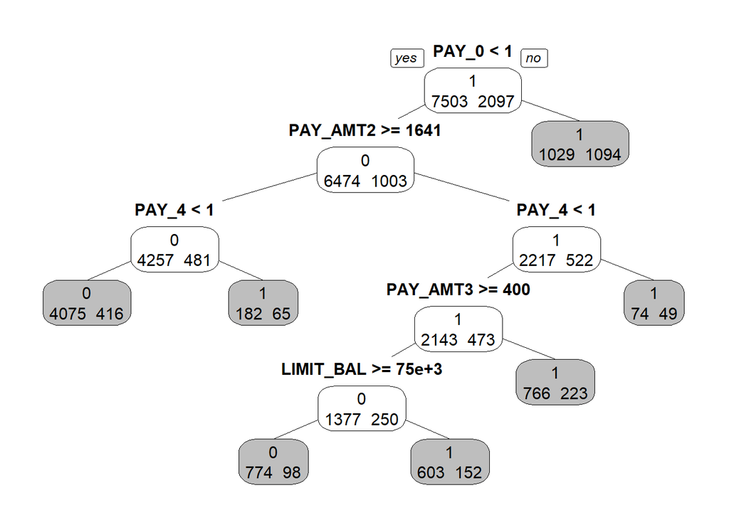

```r
prp(credit.ct, type = 1, extra = 1, varlen = -10,
    box.col = ifelse(credit.ct$frame$var == "<leaf>", 'gray', 'white'))
```

## Prediction Using Classification Tree

For a binary classification problem, there are 2 types of predictions. One is the predicted class of response (0 or 1), and the other is probability of a response being a 1. We use an additional argument type=“class” or type=“prob” to get these.

In-Sample Prediction:

```r
credit.train.ct.pred1 <- predict(credit.ct, credit.train, type = "class")
confusionMatrix(credit.train.ct.pred1, as.factor(credit.train$default), positive = "1")
```

```
## Confusion Matrix and Statistics
##
##           Reference
## Prediction    0    1
##          0 4849  514
##          1 2654 1583
##
##                Accuracy : 0.67
##                  95% CI : (0.6605, 0.6794)
##     No Information Rate : 0.7816
##     P-Value [Acc > NIR] : 1
##
##                   Kappa : 0.2933
##
##  Mcnemar's Test P-Value : <2e-16
##
##             Sensitivity : 0.7549
##             Specificity : 0.6463
##          Pos Pred Value : 0.3736
##          Neg Pred Value : 0.9042
##              Prevalence : 0.2184
##          Detection Rate : 0.1649
##    Detection Prevalence : 0.4414
##       Balanced Accuracy : 0.7006
##
##        'Positive' Class : 1
##
```

Out-of-Sample Prediction:

```r
credit.valid.ct.pred1 <- predict(credit.ct, credit.valid, type = "class")
confusionMatrix(credit.valid.ct.pred1, as.factor(credit.valid$default), positive = "1")
```

```
## Confusion Matrix and Statistics
##
##           Reference
## Prediction    0    1
##          0 1194  141
##          1  671  394
##
##                Accuracy : 0.6617
##                  95% CI : (0.6423, 0.6806)
##     No Information Rate : 0.7771
##     P-Value [Acc > NIR] : 1
##
##                   Kappa : 0.2783
##
##  Mcnemar's Test P-Value : <2e-16
##
##             Sensitivity : 0.7364
##             Specificity : 0.6402
##          Pos Pred Value : 0.3700
##          Neg Pred Value : 0.8944
##              Prevalence : 0.2229
##          Detection Rate : 0.1642
##    Detection Prevalence : 0.4437
##       Balanced Accuracy : 0.6883
##
##        'Positive' Class : 1
##
```

**Exercise:** Try type=“prob” in your prediction. What can you say about these predicted probabilities?

## Calculate the Actual Cost Using a Self-Defined Cost Function

We can get the expected cost for this tree model by defining a cost function that has the correct weights.

```r
cost <- function(r, pi){
  weight1 <- 5
  weight0 <- 1
  c1 <- (r == 1) & (pi == 0) # logical vector - true if actual 1 but predict 0
  c0 <- (r == 0) & (pi == 1) # logical vector - true if actual 0 but predict 1
  return(mean(weight1 * c1 + weight0 * c0))
}
```

Calculate the cost for the training sample using the above cost function.

```r
cost(credit.train$default, credit.train.ct.pred1)
```

```
## [1] 0.5441667
```

**Exercise:** Calculate the cost for the validation sample.

## Comparing the Performance of Classification Tree with Logistic Regression Model

We can compare this models out-of-sample performance to the logistic regression model with all predictors in it. Recall that when we search for the optimal cutoff using the same cost function, we get an optimal cutoff of around 0.23.

```r
# fit logistic regression model
credit.glm <- glm(default ~ ., data = credit.train, family = "binomial")

# get binary prediction
credit.valid.glm.pred <- as.numeric(predict(credit.glm, credit.valid, type = "response") > 0.23)

# calculate cost using validation set
cost(credit.valid$default, credit.valid.glm.pred)
```

```
## [1] 0.62
```

```r
# confusion matrix
confusionMatrix(as.factor(credit.valid.glm.pred), as.factor(credit.valid$default), positive = "1")
```

```
## Confusion Matrix and Statistics
##
##           Reference
## Prediction    0    1
##          0 1412  207
##          1  453  328
##
##                Accuracy : 0.725
##                  95% CI : (0.7067, 0.7428)
##     No Information Rate : 0.7771
##     P-Value [Acc > NIR] : 1
##
##                   Kappa : 0.318
##
##  Mcnemar's Test P-Value : <2e-16
##
##             Sensitivity : 0.6131
##             Specificity : 0.7571
##          Pos Pred Value : 0.4200
##          Neg Pred Value : 0.8721
##              Prevalence : 0.2229
##          Detection Rate : 0.1367
##    Detection Prevalence : 0.3254
##       Balanced Accuracy : 0.6851
##
##        'Positive' Class : 1
##
```

Which model do you think is better?

## ROC Curve for Classification Tree

To get the ROC curve, we get the predicted probability of *Y* being 1 from the fitted tree.

```r
credit.valid.ct.prob <- predict(credit.ct, credit.valid, type = "prob")
```

credit.valid.ct.prob has 2 columns. The first column is $P(default = 0)$, and the second column is $P(default = 1)$. **We need the second column.**

To get the ROC curve, we use:

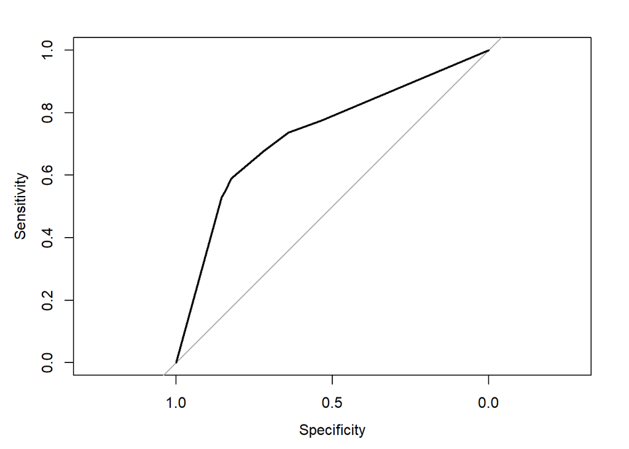

```r
library(pROC)
r <- roc(credit.valid$default, credit.valid.ct.prob[, 2])
plot.roc(r)
```

The area under the curve (AUC) is given by:

```r
auc(r)
```

```
## Area under the curve: 0.7321
```

# Pruning

In rpart(), the complexity parameter (cp) argument is one of the parameters that are used to control the complexity of the tree. The help documentation for rpart() tells you “Any split that does not decrease the overall lack of fit by a factor of cp is not attempted”. For a regression tree, the overall $R^{2}$ must increase by cp at each step. Basically, the smaller the cp value, the larger (more complex) the tree rpart() will attempt to fit. The default value for cp is 0.01.

What happens when you have a large tree? The following tree has 32 splits.

```r
housing.largetree <- rpart(MEDV ~ ., data = housing.train, cp = 0.001)
```

Plot it to see its structure.

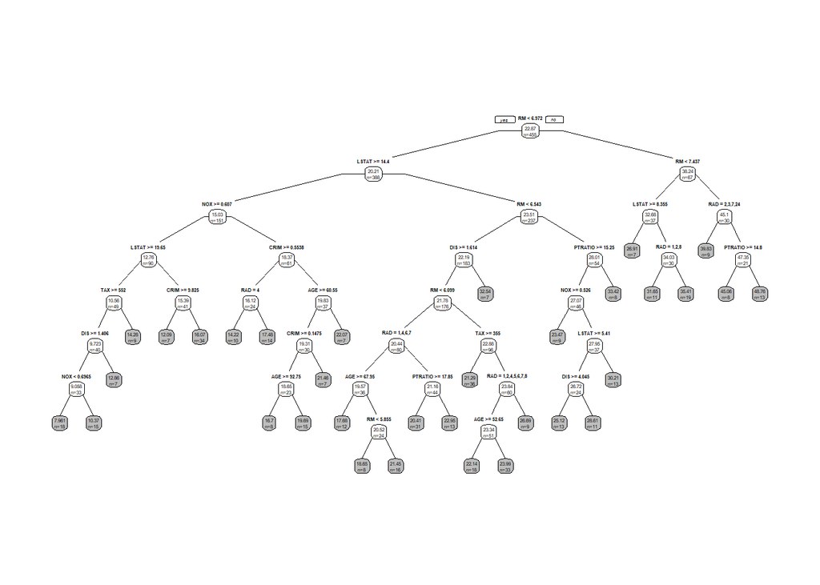

```r
prp(housing.largetree, digits = 4, type = 1, extra = 1, varlen = -10,
    box.col = ifelse(housing.largetree$frame$var == "<leaf>", 'gray', 'white'))
```

The plotcp() function gives the relationship between 10-fold cross-validation error in the training set and the size of the tree.

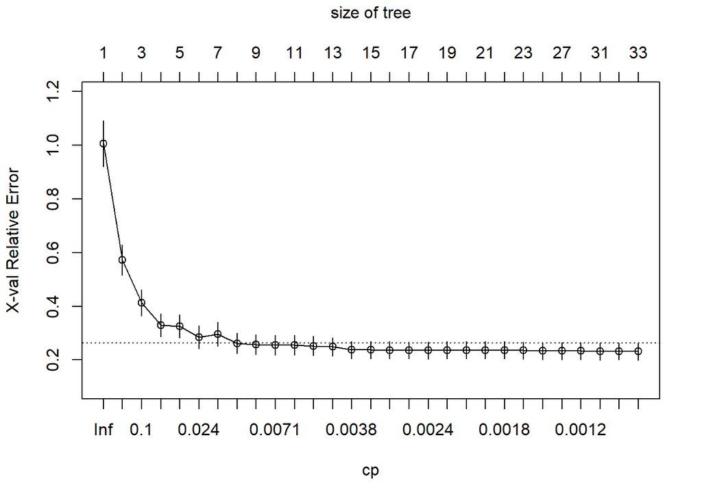

```r
plotcp(housing.largetree)
```

You can observe from the above graph that the cross-validation error (x-val) does not always decrease when the tree becomes more complex. A good choice of cp for pruning is often the leftmost value for which the mean error lies below the horizontal line. In the Boston Housing example, you may conclude that having a tree model with more than 8 splits is not helpful.

To look at the error vs. tree size more carefully, you can look at the following table:

```r
printcp(housing.largetree)
```

```
##
## Regression tree:
## rpart(formula = MEDV ~ ., data = housing.train, cp = 0.001)
##
## Variables actually used in tree construction:
## [1] AGE     CRIM    DIS     LSTAT   NOX     PTRATIO RAD     RM      TAX
##
## Root node error: 39395/455 = 86.582
##
## n= 455
##
##           CP nsplit rel error  xerror     xstd
## 1  0.4715277      0   1.00000 1.00616 0.085861
## 2  0.1686848      1   0.52847 0.57205 0.056826
## 3  0.0647970      2   0.35979 0.41352 0.048799
```

[output cut: 26 more lines]

The root node error is simply the error that results from creating no tree model at all. In the regression case, this is the mean square error (MSE) if you used the average of MEDV as the prediction for every record. Note it is the same as:

```r
sum((housing.train$MEDV - mean(housing.train$MEDV))^2) / nrow(housing.train)
```

```
## [1] 86.58186
```

The first two columns (CP and nsplit) tell you how large the tree is. “rel error” X “root node error” gives you the in-sample error. For example, using the “rel error” from the last row, calculating (rel error) X (root node error) returns the same in-sample error you would get using the predict function:

```r
mean((predict(housing.largetree) - housing.train$MEDV)^2)
```

```
## [1] 10.63393
```

```r
0.12282 * 86.582
```

```
## [1] 10.634
```

xerror gives you the cross-validation (default is 10-fold) error. You can see that the “rel error” (in-sample error) always decreases as the model becomes more complex, while the cross-validation error (measure of performance on future observations) does not. That is why we **prune** the tree to avoid overfitting the training data.

The rpart() function uses some default control parameters to avoid overfitting a large tree. The main reason for this approach is to save computation time. For example, by default, rpart() sets a cp of 0.01 and a minimum number of observations in a node to be 20. (Use ?rpart.control to learn more about these parameters.) Sometimes, we wish to change these parameter to see how more complex trees will perform, as we did above. If we have a larger than necessary tree, we can use the prune() function to specify a new cp.

```r
housing.pruned <- prune(housing.largetree, cp = 0.0090412)
housing.pruned
```

```
## n= 455
##
## node), split, n, deviance, yval
##       * denotes terminal node
##
##  1) root 455 39394.7500 22.86571
##    2) RM< 6.9715 388 15996.0500 20.21057
##      4) LSTAT>=14.4 151  3159.2690 15.02583
##        8) NOX>=0.607 90  1269.5180 12.75889
##         16) LSTAT>=19.645 49   447.4384 10.55918 *
##         17) LSTAT< 19.645 41   301.6239 15.38780 *
##        9) NOX< 0.607 61   744.8469 18.37049 *
##      5) LSTAT< 14.4 237  6191.4840 23.51392
##       10) RM< 6.543 183  3926.3490 22.18689
##         20) DIS>=1.6141 176  1437.3700 21.77500 *
##         21) DIS< 1.6141 7  1708.3970 32.54286 *
##       11) RM>=6.543 54   850.7333 28.01111 *
##    3) RM>=6.9715 67  4822.9830 38.24179
##      6) RM< 7.437 37  1171.4700 32.68378 *
##      7) RM>=7.437 30  1098.8500 45.09667
##       14) RAD=2,3,7,24 9   495.7000 39.83333 *
##       15) RAD=1,4,5,8 21   246.9724 47.35238 *
```

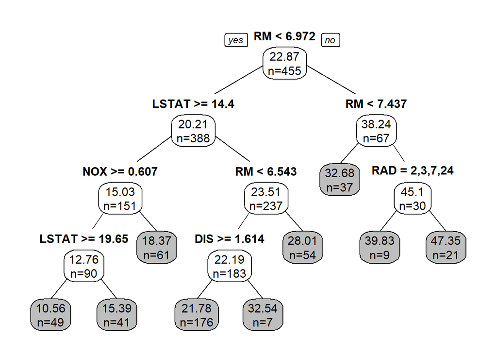

```r
prp(housing.pruned, digits = 4, type = 1, extra = 1, varlen = -10,
    box.col = ifelse(housing.pruned$frame$var == "<leaf>", 'gray', 'white'))
```

**Exercise:** Prune the classification tree for the credit default data. Start with cp=0.0001 and find a reasonable cp value. Then obtain the pruned tree.

# Summary

- Use rpart() to fit classification and regression trees.
- Understand how to interpret a tree.
- Use predict() for prediction/classifying outcomes and assessing model performance.
- Understand how to use the cp plot/table to prune a large tree.